# Assignment 01

데이터 애널리틱스

김하원

21 3월, 2024

### No.01

2023년 기준, 강서구(최대)와 도봉구(최소)의 월 별 미세먼지 대기질 추이 시각화

```r
library(ggplot2)
library(dplyr)
library(ggmap)
library(lubridate)
```

```r
#데이터불러오기
station <- read.csv('C:/Users/onlyo/OneDrive/바탕 화면/2024/4-2/데이터애널리스틱스/2주차/과제/station_coord.csv', fileEncoding = "euc-kr")
air <- read.csv('C:/Users/onlyo/OneDrive/바탕 화면/2024/4-2/데이터애널리스틱스/2주차/과제/monthly_air_quality_seoul.csv', fileEncoding = "euc-kr")


#2023년(23년 01월~12월) 측정소 별 데이터를 추출
data2023<-subset(air,  측정월 >= 202301 & 측정월 <= 202312)

#2023년 측정소 별 미세먼지 평균을 계산한 df 생성
total_mean <-aggregate(미세먼지 ~ 측정소명, data2023, mean)
total_mean
```

```
##    측정소명 미세먼지
## 1    강남구 37.41667
## 2    강동구 38.41667
## 3    강북구 37.91667
## 4    강서구 42.33333
## 5    관악구 41.50000
## 6    광진구 36.00000
## 7    구로구 39.66667
## 8    금천구 36.25000
## 9    노원구 38.66667
## 10   도봉구 34.75000
## 11 동대문구 38.75000
## 12   동작구 37.58333
## 13   마포구 35.25000
## 14 서대문구 35.33333
## 15   서초구 40.83333
## 16   성동구 37.41667
## 17   성북구 38.33333
## 18   송파구 40.08333
## 19   양천구 39.58333
## 20 영등포구 36.33333
## 21   용산구 39.58333
## 22   은평구 36.41667
## 23   종로구 36.50000
## 24     중구 34.75000
## 25   중랑구 36.00000
```

```r
#2023년 서울시의 평균 미세먼지 대기질
seoul_mean2023<-mean(total_mean$미세먼지)
seoul_mean2023
```

```
## [1] 37.82667
```

```r
#2023년 최대 미세먼지 대기질 구역: 강서구
total_mean[which.max(total_mean$미세먼지), "측정소명"]
```

```
## [1] "강서구"
```

```r
#2023년 최소 미세먼지 대기질 구역: 도봉구
total_mean[which.min(total_mean$미세먼지), "측정소명"]
```

```
## [1] "도봉구"
```

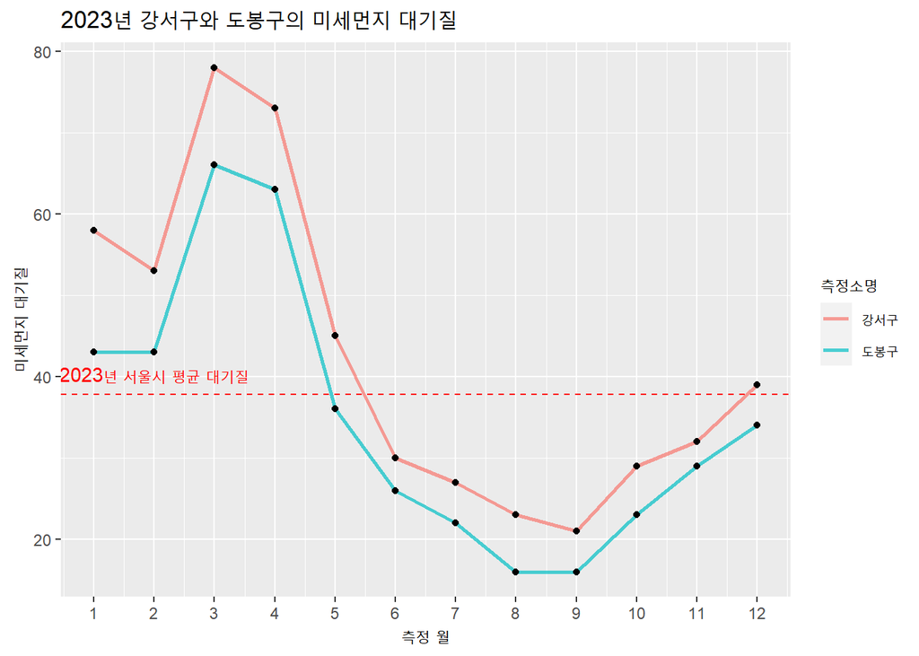

```r
#최대와 최소 측정소의 데이터 추출
MaxMin2023 <-subset(data2023, 측정소명=="강서구" | 측정소명=="도봉구")

#date 타입으로 변환하기 위해 임의로 day에 01일 추가
MaxMin2023$측정월<-as.Date(paste0(MaxMin2023$측정월, "-01"), "%Y%m-%d")
#월 추출
MaxMin2023$month <- month(MaxMin2023$측정월)

#2023년 기준, 강서구와 도봉구의 월 별 미세먼지 대기질 추이 시각화(line그래프)
ggplot(MaxMin2023, aes(x=month, y=미세먼지))+geom_line(aes(group=측정소명, color=측정소명), size=1, alpha=0.7)+geom_point()+geom_hline(yintercept = seoul_mean2023, linetype="dashed", color="red")+labs(title = "2023년 강서구와 도봉구의 미세먼지 대기질", x = "측정 월", y = "미세먼지 대기질")+ scale_x_continuous(breaks = c(01,02,03,04,05,06,07,08,09,10,11,12))+annotate("text", x = 2, y = seoul_mean2023 + 2.5, label = "2023년 서울시 평균 대기질", color ="red")
```

- 2023년 강서구와 도봉구의 미세먼지 대기질 값이 가장 높은 달은 3월, 낮은 달은 9월인 것을 확인할 수 있다. 3월부터 9월까지 하강하다가 이후부터 다시 상승하는 대기질 경향을 보인다. 두 지역 간의 대기질 차이는 1월에 가장 크고, 11월에 가장 작다.

### No.02

10년 간(2014년~2023년) 강서구의 월 별 (초)미세먼지 대기질 시각화

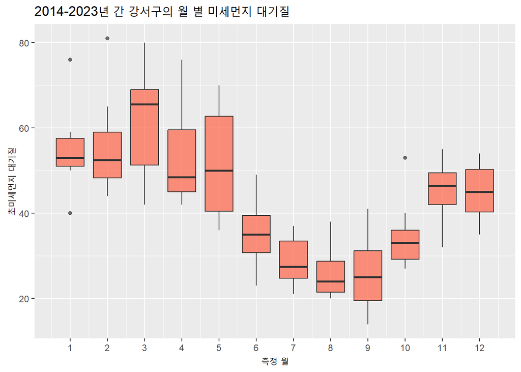

```r
#10년간 강서구의 데이터 추출
data_gangseo <- subset(air, 측정월 >= 201401 & 측정월 <= 202312 & 측정소명 == "강서구")

#date 타입으로 변환하기 위해 임의로 day에 01일 추가
data_gangseo$측정월<-as.Date(paste0(data_gangseo$측정월, "-01"), "%Y%m-%d")
#월 추출
data_gangseo$month <- month(data_gangseo$측정월)


#미세먼지 box plot 시각화
ggplot(data_gangseo, aes(x = month, y = 미세먼지, group = month)) +geom_boxplot(fill='tomato', alpha = 0.7) +labs(title="2014-2023년 간 강서구의 월 별 미세먼지 대기질", x ="측정 월", y = "초미세먼지 대기질")+ scale_x_continuous(breaks = c(01,02,03,04,05,06,07,08,09,10,11,12))
```

- 강서구의 미세먼지 대기질은 3월의 평균이 가장 높은 것을 확인할 수 있다. 특히 3월과 5월에 미세먼지 대기질의 분포가 넓다.

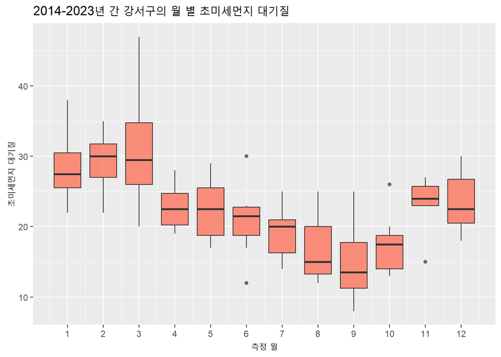

```r
#초미세먼지 box plot 시각화
ggplot(data_gangseo, aes(x = month, y = 초미세먼지, group = month)) +geom_boxplot(fill='tomato', alpha = 0.7) +labs(title="2014-2023년 간 강서구의 월 별 초미세먼지 대기질", x ="측정 월", y = "초미세먼지 대기질")+ scale_x_continuous(breaks = c(01,02,03,04,05,06,07,08,09,10,11,12))
```

- 초미세먼지의 경우, 2월의 평균이 가장 높은 것을 확인할 수 있다. 특히 3월에 초미세먼지 대기질의 분포가 가장 넓다. 미세먼지 대기질에 비해 월 별 대기질의 분포가 좁은 경향을 보인다.

### No.03

10년 간(2014~2023) 강서구의 계절 별 미세먼지 예보 비율

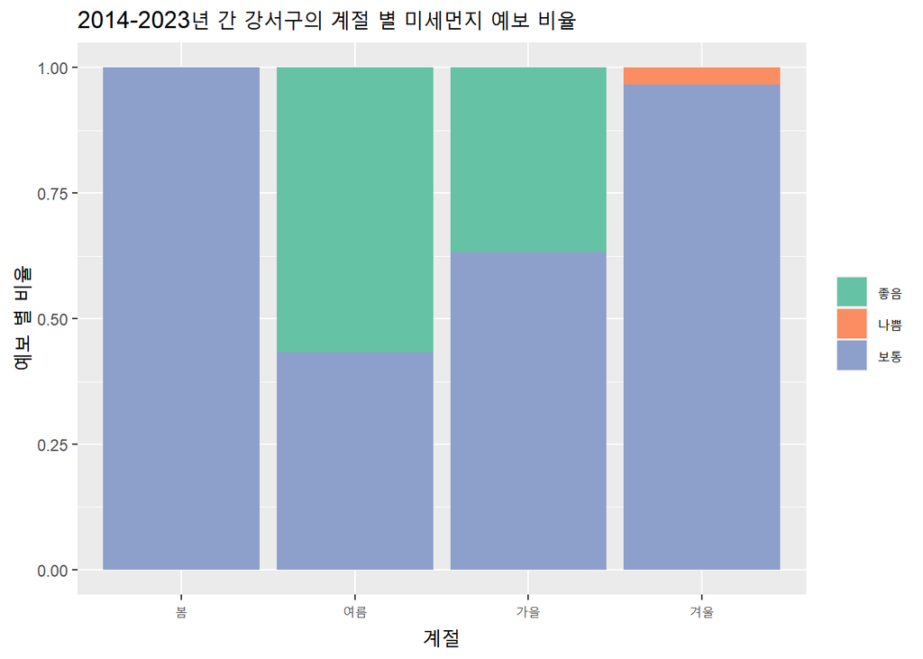

```r
#계절 판단 함수(03~05월-봄, 06~08월-여름, 09~11월-가을, 12~02월-겨울)
library(lubridate)
get_season <- function(month) {
  if(month %in% 3:5) {
    return("spring")
  } else if(month %in% 6:8) {
    return("summer")
  } else if(month %in% 9:11) {
    return("autumn")
  } else {
    return("winter")
  }
}
#월에 따른 계절 컬럼 생성
data_gangseo$season <- sapply(data_gangseo$month, get_season)

# 미세먼지 대기질에 따른 예보 판단 함수(30 이하-good, 31~80-normal, 81~150-bad, 150~ -worse)
get_rank <- function(dust) {
  if (dust <= 30) {
    return("good")
  } else if (dust <= 80) {
    return("normal")
  } else if (dust <= 150) {
    return("bad")
  } else {
    return("worse")
  }
}
# rank 열 추가
data_gangseo$rank <- sapply(data_gangseo$미세먼지, get_rank)

#누적 bar 그래프
ggplot(data_gangseo, aes(x = factor(season, levels = c("spring", "summer", "autumn", "winter")),
                         fill = factor(rank, levels = c("good", "bad", "normal", "worse"),
                                       labels = c("좋음", "나쁨","보통","매우 나쁨")))) +geom_bar(position = "fill") +labs(y = "Proportion") +scale_fill_brewer(palette = "Set2") +theme(legend.title = element_blank(),axis.title.x = element_text(size = 14), axis.title.y = element_text(size = 13)) +labs(title = "2014-2023년 간 강서구의 계절 별 미세먼지 예보 비율", x = "계절", y = "예보 별 비율") +scale_x_discrete(labels = c("봄", "여름", "가을", "겨울"))
```

- 10년 간 강서구의 미세먼지 대기질은 “좋음” 예보에 해당하는 비율이 여름(06~08월)에 가장 많았다. “나쁨” 예보에 해당하는 비율은 겨울(12~2)에서 확인할 수 있었다.

### No.04

10년 간(2014~2023) 서울시 구별 미세먼지 “좋음” 빈도 시각화

```r
#API 등록
register_stadiamaps("34cdbd27-6bd4-4097-9757-64e3f3a8910f", write = FALSE)
#서울 지도 등록
bbox_seoul <- c(left = 126.826128, bottom = 37.458073,
 right = 127.194848, top = 37.696073)
seoul <- get_stadiamap(bbox = bbox_seoul, zoom = 11, maptype =
"stamen_toner")

#10년간 서울시 데이터 추출
data10y <- subset(air,  측정월 >= 201401 & 측정월 <= 202312)

#결측값 확인
summary(data10y)
```

```
##      측정월         측정소명            미세먼지       초미세먼지
##  Min.   :201401   Length:3000        Min.   :11.00   Min.   : 5.00
##  1st Qu.:201607   Class :character   1st Qu.:30.00   1st Qu.:17.00
##  Median :201857   Mode  :character   Median :40.00   Median :22.00
##  Mean   :201857                      Mean   :40.85   Mean   :22.38
##  3rd Qu.:202106                      3rd Qu.:49.00   3rd Qu.:27.00
##  Max.   :202312                      Max.   :98.00   Max.   :55.00
##                                      NA's   :1       NA's   :1
```

```r
#결측값이 있는 행 삭제
data10y <-na.omit(data10y)
summary(data10y)
```

```
##      측정월         측정소명            미세먼지       초미세먼지
##  Min.   :201401   Length:2999        Min.   :11.00   Min.   : 5.00
##  1st Qu.:201607   Class :character   1st Qu.:30.00   1st Qu.:17.00
##  Median :201812   Mode  :character   Median :40.00   Median :22.00
##  Mean   :201856                      Mean   :40.85   Mean   :22.38
##  3rd Qu.:202107                      3rd Qu.:49.00   3rd Qu.:27.00
##  Max.   :202312                      Max.   :98.00   Max.   :55.00
```

```r
#data10y에 rank 추가
data10y$rank <- sapply(data10y$미세먼지, get_rank)
good_air <- subset(data10y, rank == "good")

#측정소명을 카운트한 도수분포표 작성
goodCounts <- as.data.frame(table(good_air$측정소명))
#station_coord와의 위도와 경도 병합을 위해 컬럼명 변경
colnames(goodCounts)[colnames(goodCounts) == "Var1"] <- "측정소명"

#측정소명 기준으로 병합
merged_data <- merge(goodCounts, station, by = "측정소명", all.x = TRUE)
merged_data
```

```
##    측정소명 Freq latitude longitude
## 1    강남구   33 37.51757  127.0475
## 2    강동구   28 37.54505  127.1368
## 3    강북구   35 37.64792  127.0119
## 4    강서구   28 37.54467  126.8352
## 5    관악구   22 37.48741  126.9271
## 6    광진구   33 37.54516  127.0954
## 7    구로구   28 37.49852  126.8899
## 8    금천구   33 37.44329  126.9051
## 9    노원구   37 37.65882  127.0685
## 10   도봉구   37 37.65431  127.0290
## 11 동대문구   34 37.57591  127.0290
## 12   동작구   32 37.48095  126.9715
## 13   마포구   29 37.55558  126.9059
## 14 서대문구   38 37.59376  126.9497
## 15   서초구   30 37.50459  126.9945
## 16   성동구   31 37.54200  127.0497
## 17   성북구   30 37.60668  127.0273
## 18   송파구   34 37.50277  127.0925
## 19   양천구   27 37.52597  126.8566
## 20 영등포구   28 37.52626  126.8960
## 21   용산구   34 37.53492  127.0002
## 22   은평구   36 37.61018  126.9332
## 23   종로구   34 37.57205  127.0050
## 24     중구   35 37.56431  126.9744
## 25   중랑구   34 37.58490  127.0940
```

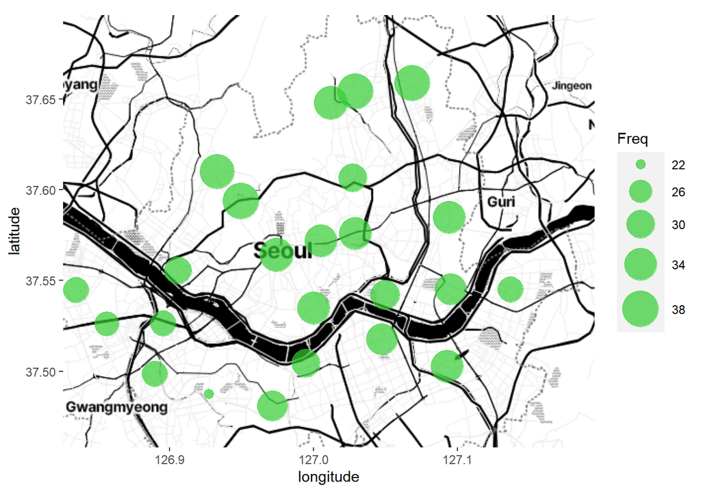

```r
#Dot Density 작성
ggmap(seoul, base_layer = ggplot(merged_data,aes(x = longitude, y = latitude, size = Freq)))+geom_point(color = "Lime Green", alpha = 0.7)+scale_size_continuous(range = c(3, 12))
```

- 10년 간 서울시의 미세먼지 대기질은 “좋음” 예보 빈도는 서울 중앙을 기준으로 서쪽에 위치할수록 적고, 북쪽에 위치할수록 많은 것을 알 수 있다. 특히 관악구의 “좋음” 예보가 적었던 것을 알 수 있다.